# Severe Weather Events Costs: Property Damage and Human Health

Patryk Soika

July 3, 2016

## Introduction

Storms and other severe weather events can cause both public health and economic problems for communities and municipalities. Many severe events can result in fatalities, injuries, and property damage, and preventing such outcomes to the extent possible is a key concern. This project involves exploring the U.S. National Oceanic and Atmospheric Administration’s (NOAA) storm database. This database tracks characteristics of major storms and weather events in the United States, including when and where they occur, as well as estimates of any fatalities, injuries, and property damage.

## Synopsis

The basic goal of this assignment is to explore the NOAA Storm Database and answer some basic questions about severe weather events. We will use the database to answer the questions below and show the code for the entire analysis. The data analysis must address the following questions:

1. Across the United States, which types of events (as indicated in the 𝙴𝚅𝚃𝚈𝙿𝙴 variable) are most harmful with respect to population health?
2. Across the United States, which types of events have the greatest economic consequences?

With regards to population health, the most destructive severe weather event is the tornado. Whether you look at injuries or fatalities, it dwarfs the next most destructive event. On the other hand, when you look at property damage, the most destructive event is the flood, with tornadoes finishing as a strong second.

On the surface, the difference makes sense. Compared to a tornado, a flood (note: not a *flash* flood) is a slow and predictable thing. While it is broad and can damage an enormous amount of property, people can remove themselves from its path with relative ease. Rapid and eratic events such as the tornado and flash flood, are harder to predict and avoid, and therefore more dangerous to the unprepared population.

## Data

The data for this assignment come in the form of a comma-separated-value file compressed via the bzip2 algorithm to reduce its size. You can download the file from the course web site:

- Storm Data

There is also some documentation of the database available. Here you will find how some of the variables are constructed/defined.

- National Weather Service Storm Data Documentation
- National Climatic Data Center Storm Events FAQ

## First Steps

### Packages Used

Before downloading and reading in the dataset, we will load several R packages. We will first check to see whether the packages are installed, and install them if they are not.

```r
get.installed.package.list <- function() {
    package_frame <- installed.packages()
    package_list <- package_frame[, 1]
    return(unique(package_list))
}
old.package.list <- get.installed.package.list()
new.package.list <- c( "dplyr", "ggplot2" , "readr" , "stringr" )
for (i in new.package.list) {
    if (i %in% old.package.list == FALSE) {
        install.packages(i)
    }
    require(i , character.only = TRUE)
}
rm( i )
```

### Download and Read In Data

```r
if(file.exists("StormData.csv.bz2")==FALSE) {
    download.file(
    "https://d396qusza40orc.cloudfront.net/repdata%2Fdata%2FStormData.csv.bz2" ,
        destfile = "StormData.csv.bz2"
    )
}
stormdata <- read_csv( "stormdata.csv.bz2" )
```

## Data Processing

There are several challenges in processing the data. First, we will trim the dataset down to the few columns relevant for the purposes of this analysis.

```r
thindata <- select(stormdata , EVTYPE , FATALITIES:PROPDMGEXP )
```

Second, “PROPDMGEXP” represents the magitude of property damage (PROPDMG), essentially a multiplier. We will create a new column “MAGNITUDE” to properly quantify this. Then we’ll create another called “ADJUSTED” to capture the values in the same scale.

```r
thindata <- mutate( thindata , "MAGNITUDE" = str_to_lower(PROPDMGEXP) )
oldmag <- unique( thindata$MAGNITUDE )
newmag <- c( 1e3 , 1e6 , 1 , 1e9, 1 , 1 , 1e5 , 1e6 , 1 , 1e4 , 1e2 , 1e3 , 1e2,
             1e7 , 1 , 1e1 , 1e8 )
for( i in 1:17 ){
    thindata <- mutate( thindata , MAGNITUDE = replace( MAGNITUDE , MAGNITUDE ==
                                                        oldmag[i] , newmag[i]))
}
thindata <- mutate( thindata , MAGNITUDE = replace ( MAGNITUDE ,
                                                     is.na(MAGNITUDE) , 1 ))
thindata$MAGNITUDE <- as.numeric(thindata$MAGNITUDE)
thindata <- mutate( thindata , ADJUSTED = PROPDMG * MAGNITUDE)
```

Third, “The only events permitted in Storm Data are listed in Table 1 of Section 2.1.1” of NATIONAL WEATHER SERVICE INSTRUCTION 10-16. There are only 48 of them. However, EVTYPE in the dataset contains nearly a thousand unique labels. We must correct the mislabeled events into those categories, remove those that were recorded inappropriately.

```r
permitted <- c( "Astronomical Low Tide" , "Avalanche" , "Blizzard" ,
                "Coastal Flood" , "Cold/Wind Chill" , "Debris Flow" ,
                "Dense Fog" , "Dense Smoke" , "Drought" , "Dust Devil" ,
                "Dust Storm" , "Excessive Heat" , "Extreme Cold/Wind Chill" ,
                "Flash Flood" , "Flood" , "Frost/Freeze" , "Funnel Cloud" ,
                "Freezing Fog" , "Hail" , "Heat" , "Heavy Rain" , "Heavy Snow" ,
                "High Surf" , "High Wind" , "Hurricane (Typhoon)" , "Ice Storm",
                "Lake-Effect Snow" , "Lakeshore Flood" , "Lightning" ,
                "Marine Hail" , "Marine High Wind" , "Marine Strong Wind" ,
                "Marine Thunderstorm Wind" , "Rip Current" , "Seiche" , "Sleet"
                , "Storm Surge/Tide" , "Strong Wind" , "Thunderstorm Wind" ,
                "Tornado" , "Tropical Depression" , "Tropical Storm" , "Tsunami"
                , "Volcanic Ash" , "Waterspout" , "Wildfire" , "Winter Storm" ,
                "Winter Weather" )
permitted <- str_to_lower( permitted )

thindata$EVTYPE <- str_to_lower(thindata$EVTYPE)
thindata <- mutate(thindata , EVTYPE = replace(EVTYPE , EVTYPE %in% sort(unique(thindata$EVTYPE))[grep("aval", (sort(unique(thindata$EVTYPE))))] , "avalanche"))
thindata <- mutate(thindata , EVTYPE = replace(EVTYPE , EVTYPE %in% sort(unique(thindata$EVTYPE))[grep("bliz", (sort(unique(thindata$EVTYPE))))] , "blizzard"))
thindata <- mutate(thindata , EVTYPE = replace(EVTYPE , EVTYPE %in% sort(unique(thindata$EVTYPE))[grep(glob2rx("*coastal*flo*"),(sort(unique(thindata$EVTYPE))))] , "coastal flood"))
thindata <- mutate(thindata , EVTYPE = replace(EVTYPE , EVTYPE %in% sort(unique(thindata$EVTYPE))[grep(glob2rx("*ex*cold*"),(sort(unique(thindata$EVTYPE))))] , "extreme cold/wind chill"))
thindata <- mutate(thindata , EVTYPE = replace(EVTYPE , EVTYPE %in% sort(unique(thindata$EVTYPE))[grep(glob2rx("*ex*wind*"),(sort(unique(thindata$EVTYPE))))] , "extreme cold/wind chill"))
thindata <- mutate(thindata , EVTYPE = replace(EVTYPE , EVTYPE %in% c("severe cold","record cold") , "extreme cold/wind chill"))
thindata <- mutate(thindata , EVTYPE = replace(EVTYPE , EVTYPE %in% c("cold","cold wave","cold weather","cold wind chill temperatures","cold temperatures","cold temperature","cold/winds") , "extreme cold/wind chill"))
thindata <- mutate(thindata , EVTYPE = replace(EVTYPE , EVTYPE %in% sort(unique(thindata$EVTYPE))[grep("drought",(sort(unique(thindata$EVTYPE))))] , "drought"))
thindata <- mutate(thindata , EVTYPE = replace(EVTYPE , EVTYPE %in% sort(unique(thindata$EVTYPE))[grep("dust dev",(sort(unique(thindata$EVTYPE))))] , "dust devil"))
thindata <- mutate(thindata , EVTYPE = replace(EVTYPE , EVTYPE %in% sort(unique(thindata$EVTYPE))[grep(glob2rx("*dust*storm*"),(sort(unique(thindata$EVTYPE))))] , "dust storm"))
thindata <- mutate(thindata , EVTYPE = replace(EVTYPE , EVTYPE %in% sort(unique(thindata$EVTYPE))[grep(glob2rx("*ex*heat*"),(sort(unique(thindata$EVTYPE))))] , "excessive heat"))
thindata <- mutate(thindata , EVTYPE = replace(EVTYPE , EVTYPE %in% sort(unique(thindata$EVTYPE))[grep("flash", (sort(unique(thindata$EVTYPE))))] , "flash flood"))
thindata <- mutate(thindata , EVTYPE = replace(EVTYPE , EVTYPE %in% sort(unique(thindata$EVTYPE))[grep(glob2rx("*lake*flood*"),(sort(unique(thindata$EVTYPE))))] , "lakeshore flood"))
thindata <- mutate(thindata , EVTYPE = replace(EVTYPE , EVTYPE %in% sort(unique(thindata$EVTYPE))[grep(glob2rx("*lake*snow*"),(sort(unique(thindata$EVTYPE))))] , "lakeshore flood"))
thindata <- mutate(thindata , EVTYPE = replace(EVTYPE , EVTYPE %in% sort(unique(thindata$EVTYPE))[grep("lightn",(sort(unique(thindata$EVTYPE))))] , "lightning"))
thindata <- mutate(thindata , EVTYPE = replace(EVTYPE , EVTYPE %in% sort(unique(thindata$EVTYPE))[grep("marine tstm wind",(sort(unique(thindata$EVTYPE))))] , "marine thunderstorm wind"))
thindata <- mutate(thindata , EVTYPE = replace(EVTYPE , EVTYPE %in% sort(unique(thindata$EVTYPE))[grep("rip",(sort(unique(thindata$EVTYPE))))] , "rip current"))
thindata <- mutate(thindata , EVTYPE = replace(EVTYPE , EVTYPE %in% sort(unique(thindata$EVTYPE))[grep("sleet",(sort(unique(thindata$EVTYPE))))] , "sleet"))
thindata <- mutate(thindata , EVTYPE = replace(EVTYPE , EVTYPE %in% sort(unique(thindata$EVTYPE))[grep("surge",(sort(unique(thindata$EVTYPE))))] , "storm surge/tide"))
thindata <- mutate(thindata , EVTYPE = replace(EVTYPE , EVTYPE %in% sort(unique(thindata$EVTYPE))[grep(glob2rx("*strong*wind*"),(sort(unique(thindata$EVTYPE))))] , "strong wind"))
thindata <- mutate(thindata , EVTYPE = replace(EVTYPE , EVTYPE %in% sort(unique(thindata$EVTYPE))[grep(glob2rx("*th*wind*"),(sort(unique(thindata$EVTYPE))))] , "thunderstorm wind"))
thindata <- mutate(thindata , EVTYPE = replace(EVTYPE , EVTYPE %in% sort(unique(thindata$EVTYPE))[grep("torn",(sort(unique(thindata$EVTYPE))))] , "tornado"))
thindata <- mutate(thindata , EVTYPE = replace(EVTYPE , EVTYPE %in% sort(unique(thindata$EVTYPE))[grep("tropical storm",(sort(unique(thindata$EVTYPE))))] , "tropical storm"))
thindata <- mutate(thindata , EVTYPE = replace(EVTYPE , EVTYPE %in% sort(unique(thindata$EVTYPE))[grep("volcanic ash",(sort(unique(thindata$EVTYPE))))] , "volcanic ash"))
thindata <- mutate(thindata , EVTYPE = replace(EVTYPE , EVTYPE %in% sort(unique(thindata$EVTYPE))[grep("waters",(sort(unique(thindata$EVTYPE))))] , "waterspout"))
thindata <- mutate(thindata , EVTYPE = replace(EVTYPE , EVTYPE %in% sort(unique(thindata$EVTYPE))[grep("wild",(sort(unique(thindata$EVTYPE))))] , "wildfire"))
thindata <- mutate(thindata , EVTYPE = replace(EVTYPE , EVTYPE %in% sort(unique(thindata$EVTYPE))[grep(glob2rx("*winter*storm*"),(sort(unique(thindata$EVTYPE))))] , "winter storm"))
thindata <- mutate(thindata , EVTYPE = replace(EVTYPE , EVTYPE %in% sort(unique(thindata$EVTYPE))[grep(glob2rx("*winter*weather*"),(sort(unique(thindata$EVTYPE))))] , "winter weather"))
thindata <- mutate(thindata , EVTYPE = replace(EVTYPE , EVTYPE %in% sort(unique(thindata$EVTYPE))[grep(glob2rx("*winter*mix*"),(sort(unique(thindata$EVTYPE))))] , "winter weather"))

thindata <- mutate(thindata , EVTYPE = replace(EVTYPE , (EVTYPE %in% permitted) == FALSE , NA ))
```

## Exploratory Analysis

Now that the dataset has been processed, we will create plots to illustrate the most dangerous sever weather events–one each for human injuries, human fatalities, and property damage. For each category, we will aggregate the sum of the harm caused by the type of weather event, and focus our plots upon the top five.

### Property Damage

[figure not shown]

```r
propdamage <- aggregate( ADJUSTED ~ EVTYPE , data = thindata , FUN = sum )
topdamage <- arrange( propdamage , desc(ADJUSTED) )[1:5,]
topdamage <- mutate( topdamage , ADJUSTED = ADJUSTED / 1e9 )

quickplot(
    x = EVTYPE,
    y = ADJUSTED ,
    data = topdamage ,
    color = EVTYPE ,
    ylim = c(0, 150),
    xlab = "Event Type" ,
    ylab = "Property Damage (millions of US Dollars)" ,
    main = "Top Five Extreme Weather Events for Property Damage"
) + geom_bar(stat = "identity")
```

### Human Injury

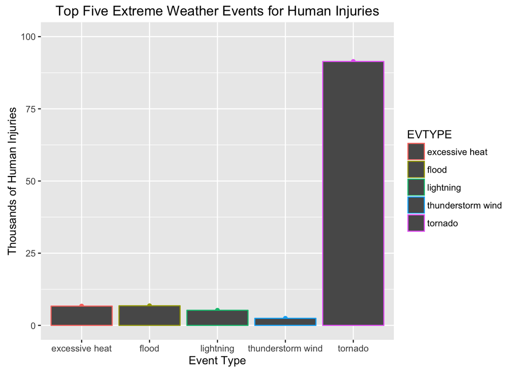

```r
injury <- aggregate( INJURIES ~ EVTYPE , data = thindata , FUN = sum )
topinjury <- arrange( injury , desc(INJURIES) )[1:5,]
topinjury <- mutate( topinjury , INJURIES = INJURIES / 1e3 )

quickplot(
    x = EVTYPE,
    y = INJURIES ,
    data = topinjury ,
    color = EVTYPE ,
    ylim = c(0, 100),
    xlab = "Event Type" ,
    ylab = "Thousands of Human Injuries" ,
    main = "Top Five Extreme Weather Events for Human Injuries"
) + geom_bar(stat = "identity")
```

### Human Fatality

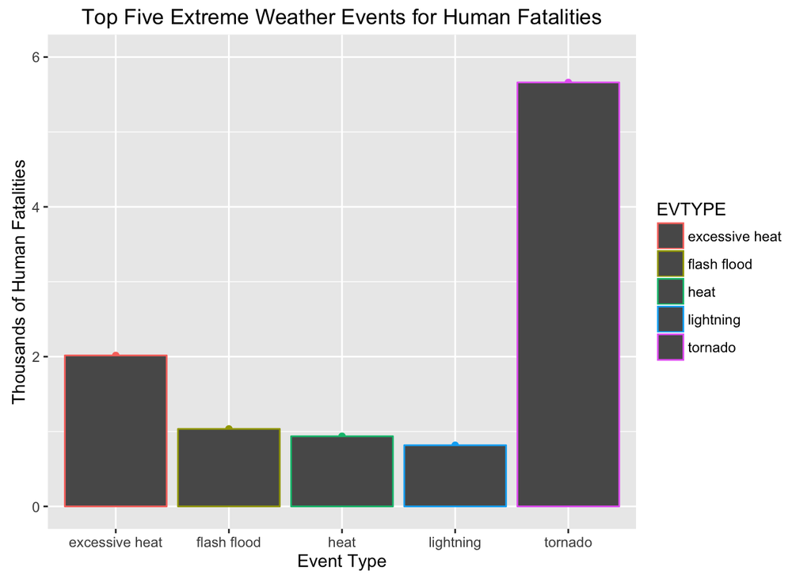

[output not shown]

```r
fatality <- aggregate( FATALITIES ~ EVTYPE , data = thindata , FUN = sum )
topfatality <- arrange( fatality , desc(FATALITIES) )[1:5,]
topfatality <- mutate( topfatality , FATALITIES = FATALITIES / 1e3 )

quickplot(
    x = EVTYPE,
    y = FATALITIES ,
    data = topfatality ,
    color = EVTYPE ,
    ylim = c(0, 6),
    xlab = "Event Type" ,
    ylab = "Thousands of Human Fatalities" ,
    main = "Top Five Extreme Weather Events for Human Fatalities"
) + geom_bar(stat = "identity")
```